# Tooploox_ver2

# Data Partitioning

Here we randomly divide our dataset as : 90% observations in training dataset 10% observations in testing dataset

```r
set.seed(2017)
indxTrainSet <- createDataPartition(y = data_Video_views_wo_outliers_na$View_hour_168_log , p=0.90)
train <- data_Video_views_wo_outliers_na[indxTrainSet$Resample1, ]
test <- data_Video_views_wo_outliers_na[-indxTrainSet$Resample1, ]
```

# Linear Regression

LINEAR REGRESSION is an approch of modelling the relationship between a scalar dependent variable y and one or more explanatory variable(or independent variables) denoted x. one explanatory variable -> single input LR more then one explanatory variable -> multiple input LR # single input Linear Regression

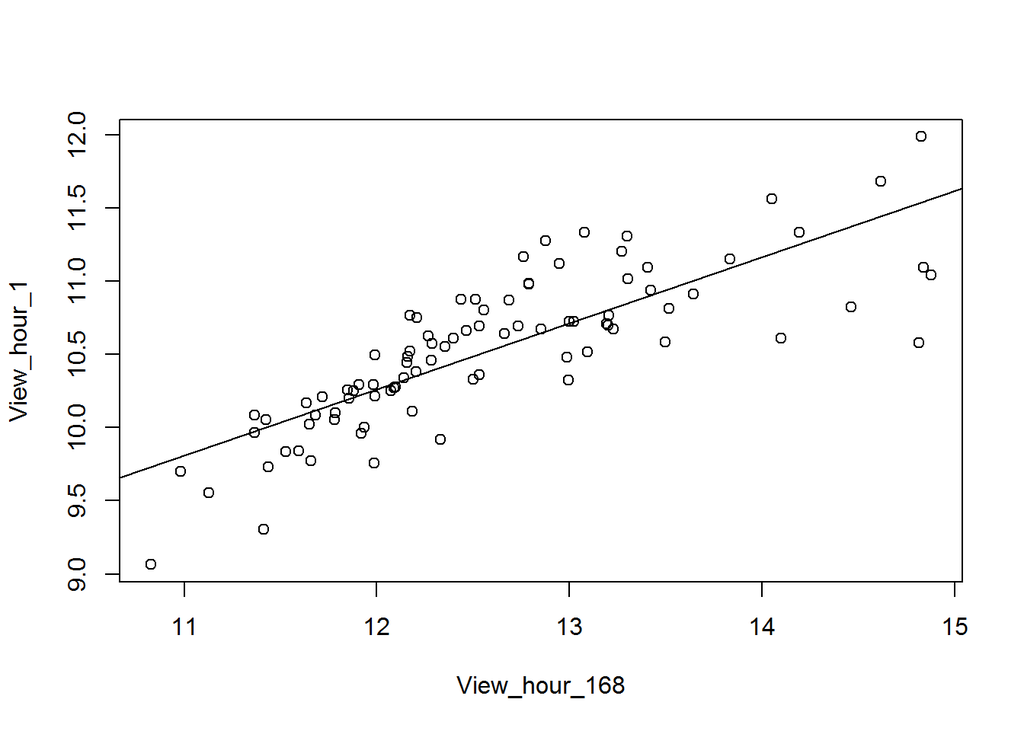

```r
View_hour_168 = test$View_hour_168_log
View_hour_1 = test$View_hour_1_log
plot(View_hour_1~View_hour_168)
abline(lm(View_hour_1~View_hour_168))
```

```r
# Here is plot of Linear Regression Model between View Hours 1 and 168.
# Next we create a function for the same.
linear_model_single_input = function(dataset, n) {
formula = as.formula(paste0("View_hour_168_log ~ View_hour_",n,"_log"))
return(lm(formula, data=data_Video_views_wo_outliers_na))
}
linear_model_single_input(train, 1)
```

```
##
## Call:
## lm(formula = formula, data = data_Video_views_wo_outliers_na)
##
## Coefficients:
##     (Intercept)  View_hour_1_log
##           1.731            1.041
```

```r
summary(linear_model_single_input(train, 1))
```

```
##
## Call:
## lm(formula = formula, data = data_Video_views_wo_outliers_na)
##
## Residuals:
##     Min      1Q  Median      3Q     Max
## -1.3022 -0.4400 -0.2056  0.2592  6.4519
##
## Coefficients:
##                 Estimate Std. Error t value Pr(>|t|)
## (Intercept)      1.73118    0.39904   4.338  1.6e-05 ***
## View_hour_1_log  1.04063    0.03816  27.267  < 2e-16 ***
## ---
## Signif. codes:  0 '***' 0.001 '**' 0.01 '*' 0.05 '.' 0.1 ' ' 1
##
## Residual standard error: 0.7086 on 899 degrees of freedom
## Multiple R-squared:  0.4527, Adjusted R-squared:  0.4521
## F-statistic: 743.5 on 1 and 899 DF,  p-value: < 2.2e-16
```

The model above is achieved by using the lm() function and the output is called using the summary() function on the model. Output describes: Formula Call -> formula used to fit the model , here View_hour_168_log vs ‘any other View hour’

Residuals -> Residuals are the summary of difference between the actual observed response values and the predicted.

Coefficient - Estimate ->intercept and slope in the linear model. Coefficient - Standard Error ->measure of average of actual vs predicted

The coefficient t-value -> measure of how many standard deviations our coefficient estimate is far away from 0

Residual Standard Error -> measure of the quality of a linear regression fit.

The R-squared statistic -> measure of how well the model is fitting the actual data.

F-statistic -> indicator of whether there is a relationship between our predictor and the response variables.

# Multiple input Linear Regression

```r
lm(formula = View_hour_168_log ~ View_hour_1_log + View_hour_2_log , data = train )
```

```
##
## Call:
## lm(formula = View_hour_168_log ~ View_hour_1_log + View_hour_2_log,
##     data = train)
##
## Coefficients:
##     (Intercept)  View_hour_1_log  View_hour_2_log
##         -0.8963          -0.3518           1.5723
```

```r
linear_model_multiple_input = function(dataset, n){
column_names = paste0(paste0("View_hour_",1:n,"_log"), collapse=" + ")
formula = as.formula(paste0("View_hour_168_log ~" , column_names))
return(lm(formula, data=dataset))
}
linear_model_multiple_input(train, 5)
```

```
##
## Call:
## lm(formula = formula, data = dataset)
##
## Coefficients:
##     (Intercept)  View_hour_1_log  View_hour_2_log  View_hour_3_log
##        -1.25217         -0.07082          0.27139         -0.94381
## View_hour_4_log  View_hour_5_log
##        -2.73777          4.64481
```

```r
summary(linear_model_multiple_input(train, 5))
```

```
##
## Call:
## lm(formula = formula, data = dataset)
##
## Residuals:
##      Min       1Q   Median       3Q      Max
## -1.48538 -0.29133 -0.09756  0.15592  2.55850
##
## Coefficients:
##                 Estimate Std. Error t value Pr(>|t|)
## (Intercept)     -1.25217    0.29328  -4.270 2.19e-05 ***
## View_hour_1_log -0.07082    0.06204  -1.142   0.2540
## View_hour_2_log  0.27139    0.15125   1.794   0.0731 .
## View_hour_3_log -0.94381    0.46544  -2.028   0.0429 *
## View_hour_4_log -2.73777    0.69771  -3.924 9.45e-05 ***
## View_hour_5_log  4.64481    0.42414  10.951  < 2e-16 ***
## ---
## Signif. codes:  0 '***' 0.001 '**' 0.01 '*' 0.05 '.' 0.1 ' ' 1
##
## Residual standard error: 0.4485 on 807 degrees of freedom
## Multiple R-squared:  0.7835, Adjusted R-squared:  0.7822
## F-statistic: 584.2 on 5 and 807 DF,  p-value: < 2.2e-16
```

# mean Relative Squared Error (mRSE)

```r
rMSE = function(model , test_dataset){
predictions = predict(model, newdata = test_dataset)
predictions[is.na(predictions)] <- 0
squares = ((predictions / test_dataset$View_hour_168_log) - 1)^2
sum(squares) / nrow(test_dataset)
}
rMSE(linear_model_single_input(train, 24), test)
```

```
## [1] 0.0003553896
```

# Plotting mRSE

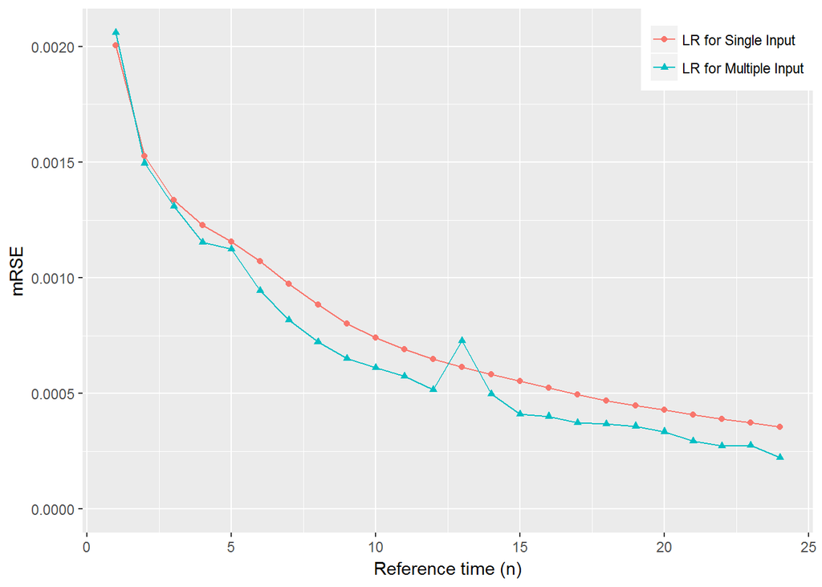

```r
result_matrix = NULL
model_type = NULL
error = NULL
for (reference_time in 1:24) {

model_type = "LR for Single Input"
error = rMSE(linear_model_single_input(train, reference_time), test)
result_matrix= rbind(result_matrix, data.frame( reference_time,model_type,error))

model_type = "LR for Multiple Input"
error = rMSE(linear_model_multiple_input(train, reference_time), test)
result_matrix= rbind(result_matrix, data.frame( reference_time,model_type,error))

}
ggplot(data = result_matrix, aes(x=reference_time, y=error, color = model_type)) +
geom_line() + geom_point(aes(shape=model_type)) +
xlab("Reference time (n)") +
ylab("mRSE") +
ylim(0, max(result_matrix$error))+
theme(legend.position=c(1,1) , legend.justification=c(1,1), legend.title = element_blank())
```